# Data modeling in RethinkDB

There are two ways to model relationships between documents in RethinkDB:

- By using **embedded arrays**.
- By linking documents stored in **multiple tables** (similar to traditional relational database systems).

Let’s explore the advantages and disadvantages of each approach. We’ll use a simple blog database that stores information about authors and their posts to demonstrate them.

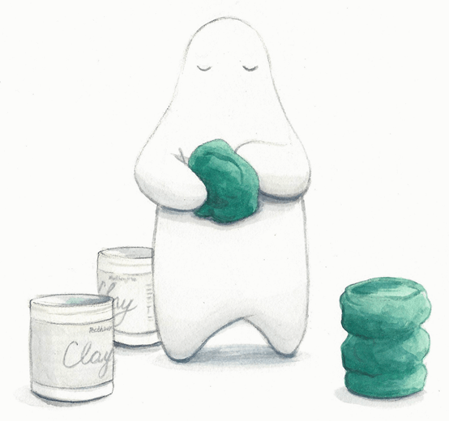

## Using embedded arrays

We can model the relationship between authors and posts by using embedded arrays as follows. Consider this example document in the table `authors`:

```json
{
  "id": "7644aaf2-9928-4231-aa68-4e65e31bf219",
  "name": "William Adama", "tv_show": "Battlestar Galactica",
  "posts": [
    {"title": "Decommissioning speech", "content": "The Cylon War is long over..."},
    {"title": "We are at war", "content": "Moments ago, this ship received..."},
    {"title": "The new Earth", "content": "The discoveries of the past few days..."}
  ]
}
```

The `authors` table contains a document for each author. Each document contains information about the relevant author and a field `posts` with an array of posts for that author. In this case the query to retrieve all authors with their posts is simple:

```python
# Retrieve all authors with their posts
r.db("blog").table("authors").run()

# Retrieve a single author with her posts
r.db("blog").table("authors").get(AUTHOR_ID).run()
```

> **Advantages of using embedded arrays:**
> - Queries for accessing authors and posts tend to be simpler.
> - The data is often colocated on disk. If you have a dataset that doesn’t fit into RAM, data is loaded from disk faster.
> - Any update to the authors document atomically updates both the author data and the posts data.

> **Disadvantages of using embedded arrays:**
> - Deleting, adding or updating a post requires loading the entire `posts` array, modifying it, and writing the entire document back to disk.
> - Because of the previous limitation, it’s best to keep the size of the `posts` array to no more than a few hundred documents.

## Linking documents in multiple tables

You can use a relational data modeling technique and create two tables to store your data. A typical document in the `authors` table would look like this:

```json
{
  "id": "7644aaf2-9928-4231-aa68-4e65e31bf219",
  "name": "William Adama",
  "tv_show": "Battlestar Galactica"
}
```

A typical document in the `posts` table would look like this:

```json
{
  "id": "064058b6-cea9-4117-b92d-c911027a725a",
  "author_id": "7644aaf2-9928-4231-aa68-4e65e31bf219",
  "title": "Decommissioning speech",
  "content": "The Cylon War is long over..."
}
```

Every post contains an `author_id` field that links each post to its author. We can retrieve all posts for a given author as follows:

```python
# If we have a secondary index on `author_id` in the table `posts`
r.db("blog").table("posts").
  get_all("7644aaf2-9928-4231-aa68-4e65e31bf219", index="author_id").
  run()

# If we didn't build a secondary index on `author_id`
r.db("blog").table("posts").
  filter({"author_id": "7644aaf2-9928-4231-aa68-4e65e31bf219"}).
  run()
```

In a relational database, we’d use a `JOIN` here; in RethinkDB, we use the `eq_join` command. To get all posts along with the author information for William Adama:

```python
# In order for this query to work, we need to have a secondary index
# on the `author_id` field of the table `posts`.
r.db("blog").table("authors").get_all("7644aaf2-9928-4231-aa68-4e65e31bf219").eq_join(
    'id',
    r.db("blog").table("posts"),
    index='author_id'
).zip().run()
```

Note that the values for `author_id` correspond to the `id` field of the author, which allows us to link the documents.

> **Advantages of using multiple tables:**
> - Operations on authors and posts don’t require loading the data for every post for a given author into memory.
> - There is no limitation on the number of posts, so this approach is more suitable for large amounts of data.

> **Disadvantages of using multiple tables:**
> - The queries linking the data between the authors and their posts tend to be more complicated.
> - With this approach you cannot atomically update both the author data and the posts data.

## Read more

There’s a separate article, Table joins in RethinkDB, with much more information about the multiple-table approach, including how to do the ReQL equivalents of inner, outer and cross joins. If you aren’t sure which schema to use, ask us on [Stack Overflow](http://stackoverflow.com/questions/ask) or join the `#rethinkdb` IRC channel on [Freenode](http://www.freenode.org/).

© RethinkDB contributors  
Licensed under the Creative Commons Attribution-ShareAlike 3.0 Unported License.  
https://rethinkdb.com/docs/data-modeling/